# sigident - Howto Microarray

The R package `sigident` is the core package of the `sigident` package framework. This framework consists of several packages which can be used to perform analyses of gene signatures. The following packages are included in the framework: * Core package: sigident * Data preprocessing: sigident.preproc * Functional analyses: sigident.func

# Prerequisites and installation

## Install sigident.preproc package

```r
options('repos' = 'https://ftp.fau.de/cran/')
install.packages("devtools")
devtools::install_git("https://gitlab.miracum.org/clearly/sigident.preproc.git",
                      upgrade = "always")
```

## Install sigident.func package

```r
devtools::install_git("https://gitlab.miracum.org/clearly/sigident.func.git",
                      upgrade = "always")
```

## Install sigident package

```r
devtools::install_git("https://gitlab.miracum.org/clearly/sigident.git")
```

# Preprocessing

In order to use this R package and its functions, you need to prepare a merged gene expression dataset. The workflow to achieve this is presented in the following by making use of the R package `sigident.preproc`.

For a more detailed background and description of the following steps please view the `sigident.preproc` package’s [vignette](https://gitlab.miracum.org/clearly/sigident_vignettes).

## Initialization of important variables

```r
library(sigident)
```

```r
library(sigident.preproc)
library(sigident.func)
library(knitr)

# initialize filePath:
filePath <- tempdir()

# define datadir
maindir <- "./geodata/"
datadir <- paste0(maindir, "data/")
dir.create(maindir)
dir.create(datadir)

# define plotdir
plotdir <- "./plots/"
dir.create(plotdir)

# define idtype
idtype = "affy"
```

## Define list that contains a representation of the studies metadata

```r
studiesinfo <- list(
  "GSE18842" = list(
    setid = 1,
    targetcolname = "source_name_ch1",
    targetlevelname = "Human Lung Tumor",
    controllevelname = "Human Lung Control"
    ),

  "GSE19804" = list(
    setid = 1,
    targetcolname = "source_name_ch1",
    targetlevelname = "frozen tissue of primary tumor",
    controllevelname = "frozen tissue of adjacent normal"
  ),

  "GSE19188" = list(
    setid = 1,
    targetcolname = "characteristics_ch1",
    controllevelname = "tissue type: healthy",
    targetlevelname = "tissue type: tumor",
    use_rawdata = TRUE
  )
)
```

## Load GEO datasets

All downloaded datasets will be assigned to the global environment.

```r
sigident.preproc::load_geo_data(
  studiesinfo = studiesinfo,
  datadir = datadir,
  plotdir = plotdir,
  idtype = idtype,
  viz_batch_boxp = F,
  viz_batch_gpca = F
)
```

### Visualize batch effect

By using the argument `viz_batch_boxp = TRUE` and `viz_batch_gpca = TRUE`, one can visualize batch effects before and after correction with two methods: boxplots and gPCA and store them in the directory specified in `plotdir`. For further details please view the package vignette of the `sigident.preproc` R package. Due to the ressource intensive calculations of the plots, this argument is set to FALSE here.

# Preparations for utilizing the sigident package

Before using the `sigident` package, these variables need to be defined properly. One could use them also as arguments directly in the respective function. However, to keep the code clearer we define them here at the beginning and refer at each function to the respective variable. `idtype` and `plotdir` have already been defined during the preprocessing steps.

In order to use this R package and its functions, you need to prepare a merged gene expression dataset. The workflow to achieve this is presented in the following by making use of the R package `sigident.preproc`.

For a detailed background on the following steps please view the `sigident.preproc` package’s [vignette](https://gitlab.miracum.org/clearly/sigident_vignettes).

```r
# general
csvdir <- "./csv/"
dir.create(csvdir)

# enrichment analysis
species <- "Hs"
OrgDb <- "org.Hs.eg.db"
organism <- "hsa"
#pathwayid <- "hsa04110" # Cell Cycle
pathwayid <- "hsa04151" # PI3K-Akt

# diagnostic signature
seed <- 111
split <- 0.8
nfolds <- 10
```

# DEG analysis

For a detailed background and description of the following steps please view the `sigident.func` package’s vignette.

```r
# define the false discovery rate here
fdr <- 0.05

genes <- sigident.func::identify_degs(mergeset = mergeset,
                                      diagnosis = diagnosis,
                                      q_value = fdr)

# heatmap creation
filename <- paste0(plotdir, "DEG_heatmap.png")
# create colors for map
ht_colors <- sigident.func::color_heatmap(sample_metadata = sample_metadata)
sigident.func::plot_deg_heatmap(mergeset = mergeset,
                                genes = genes,
                                patientcolors = ht_colors,
                                filename = filename)
```

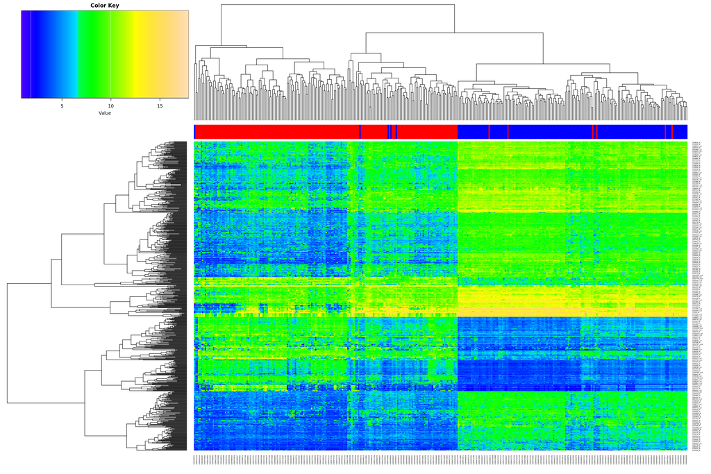

```r
knitr::include_graphics(filename)
```

```r
deg_info <- sigident.func::export_deg_annotations(mergedset = mergedset,
                                                  genes = genes,
                                                  idtype = idtype)
data.table::fwrite(deg_info, paste0(csvdir, "DEG_info.csv"))
```

```r
dim(deg_info)
```

```
#> [1] 699   5
```

```r
knitr::kable(head(deg_info))
```

| probe_ID | gene_symbol | gene_title | genebank_accession | entrez_id |
| --- | --- | --- | --- | --- |
| 1552318_at | GIMAP1 | GTPase, IMAP family member 1 | AK091818 | 170575 |
| 1552509_a_at | CD300LG | CD300 molecule-like family member g | NM_145273 | 146894 |
| 1552619_a_at | ANLN | anillin, actin binding protein | NM_018685 | 54443 |
| 1552767_a_at | HS6ST2 | heparan sulfate 6-O-sulfotransferase 2 | NM_147174 | 90161 |
| 1552797_s_at | PROM2 | prominin 2 | NM_144707 | 150696 |
| 1553105_s_at | DSG2 | desmoglein 2 | NM_001943 | 1829 |

```r
deg_results <- sigident.func::limma_top_table(mergeset = mergeset,
                                              diagnosis = diagnosis,
                                              q_value = fdr)
data.table::fwrite(deg_results, paste0(csvdir, "DEG_results.csv"))
```

```r
dim(deg_results)
```

```
#> [1] 699   3
```

```r
knitr::kable(head(deg_results))
```

|  | Probe ID | logFC | adj.q_value |
| --- | --- | --- | --- |
| 217046_s_at | 217046_s_at | -4.210404 | 0 |
| 210081_at | 210081_at | -5.357901 | 0 |
| 209470_s_at | 209470_s_at | -4.554046 | 0 |
| 209469_at | 209469_at | -3.945938 | 0 |
| 206209_s_at | 206209_s_at | -4.396728 | 0 |
| 209904_at | 209904_at | -4.090455 | 0 |

```r
rm(deg_info, deg_results, studiesinfo)
gc()
```

# Functional analysis

## Gene enrichment

For a detailed background and description of the following steps please view the `sigident.func` package’s [vignette](https://gitlab.miracum.org/clearly/sigident_vignettes).

```r
deg_entrez <- unique(mergedset@featureData@data$ENTREZ_GENE_ID)
deg_entrez <- deg_entrez[deg_entrez != ""]
```

## Test for over-representation

```r
enr_topgo <- sigident.func::extract_go_terms(gene = deg_entrez,
                                             species = species)
data.table::fwrite(enr_topgo, paste0(csvdir, "Top_GO.csv"))
```

```r
dim(enr_topgo)
```

```
#> [1] 20  5
```

```r
knitr::kable(head(enr_topgo))
```

|  | Term | Ont | N | DE | P.DE |
| --- | --- | --- | --- | --- | --- |
| GO:0044444 | cytoplasmic part | CC | 9735 | 9061 | 0 |
| GO:0005737 | cytoplasm | CC | 11625 | 10688 | 0 |
| GO:0005515 | protein binding | MF | 11807 | 11015 | 0 |
| GO:0005488 | binding | MF | 15267 | 13662 | 0 |
| GO:0003674 | molecular_function | MF | 17697 | 15487 | 0 |
| GO:0005622 | intracellular | CC | 15073 | 13258 | 0 |

```r
enr_topkegg <- sigident.func::extract_kegg_terms(gene = deg_entrez,
                                                 species = species)
data.table::fwrite(enr_topkegg, paste0(csvdir, "Top_KEGG.csv"))
```

```r
dim(enr_topkegg)
```

```
#> [1] 20  4
```

```r
knitr::kable(head(enr_topkegg))
```

|  | Pathway | N | DE | P.DE |
| --- | --- | --- | --- | --- |
| path:hsa05200 | Pathways in cancer | 531 | 515 | 0 |
| path:hsa01100 | Metabolic pathways | 1490 | 1383 | 0 |
| path:hsa05132 | Salmonella infection | 214 | 211 | 0 |
| path:hsa04151 | PI3K-Akt signaling pathway | 354 | 341 | 0 |
| path:hsa05165 | Human papillomavirus infection | 330 | 318 | 0 |
| path:hsa04360 | Axon guidance | 181 | 179 | 0 |

```r
enr_fitlm <- sigident.func::go_diff_reg(
  mergeset = mergeset,
  idtype = idtype,
  diagnosis = diagnosis,
  entrezids = mergedset@featureData@data$ENTREZ_GENE_ID
)

enr_fitlm_topgo <- sigident.func::extract_go_terms(
  gene = enr_fitlm,
  species = species,
  fdr = 0.01
)
data.table::fwrite(enr_fitlm_topgo, paste0(csvdir, "Top_GO_fitlm.csv"))
```

```r
dim(enr_fitlm_topgo)
```

```
#> [1] 20  7
```

```r
knitr::kable(head(enr_fitlm_topgo))
```

|  | Term | Ont | N | Up | Down | P.Up | P.Down |
| --- | --- | --- | --- | --- | --- | --- | --- |
| GO:0043231 | intracellular membrane-bounded organelle | CC | 10084 | 4998 | 3472 | 0 | 0 |
| GO:0044424 | intracellular part | CC | 13248 | 6219 | 4704 | 0 | 0 |
| GO:0005622 | intracellular | CC | 13258 | 6221 | 4711 | 0 | 0 |
| GO:0070013 | intracellular organelle lumen | CC | 4981 | 2788 | 1708 | 0 | 0 |
| GO:0031974 | membrane-enclosed lumen | CC | 4981 | 2788 | 1708 | 0 | 0 |
| GO:0043233 | organelle lumen | CC | 4981 | 2788 | 1708 | 0 | 0 |

```r
enr_fitlm_topkegg <- sigident.func::extract_kegg_terms(
  gene = enr_fitlm,
  species = species
)
data.table::fwrite(enr_fitlm_topkegg, paste0(csvdir, "Top_KEGG_fitlm.csv"))
```

```r
dim(enr_fitlm_topkegg)
```

```
#> [1] 20  6
```

```r
knitr::kable(head(enr_fitlm_topkegg))
```

|  | Pathway | N | Up | Down | P.Up | P.Down |
| --- | --- | --- | --- | --- | --- | --- |
| path:hsa05132 | Salmonella infection | 211 | 77 | 131 | 0.9962602 | 0.0000000 |
| path:hsa05200 | Pathways in cancer | 515 | 230 | 258 | 0.6344687 | 0.0000000 |
| path:hsa03013 | RNA transport | 143 | 113 | 41 | 0.0000000 | 0.8632953 |
| path:hsa04380 | Osteoclast differentiation | 126 | 37 | 86 | 0.9999171 | 0.0000000 |
| path:hsa04144 | Endocytosis | 234 | 94 | 136 | 0.9513970 | 0.0000000 |
| path:hsa04010 | MAPK signaling pathway | 282 | 113 | 157 | 0.9674851 | 0.0000000 |

## GO enrichment analysis

```r
enr_analysis <- sigident.func::go_enrichment_analysis(
  gene = deg_entrez,
  org_db = OrgDb,
  organism = organism,
  fitlm = enr_fitlm,
  pathwayid = pathwayid,
  species = organism,
  plotdir = plotdir
)
```

```r
filename <- paste0(plotdir, "/", pathwayid, ".png")
```

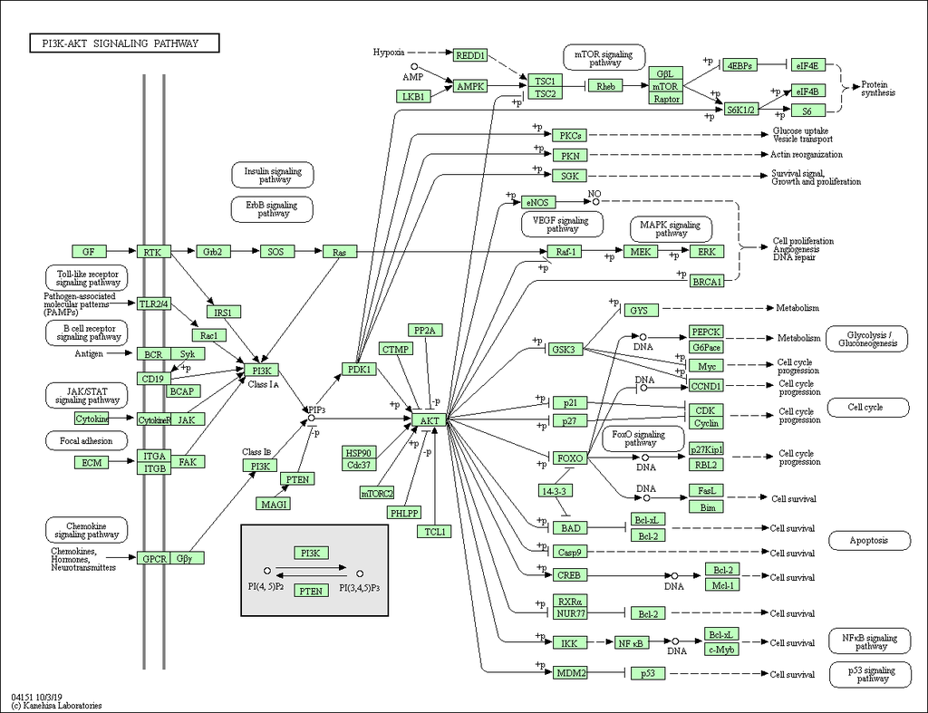

```r
knitr::include_graphics(filename)
```

```r
filename <- paste0(plotdir, "/", pathwayid, ".pathview.png")
```

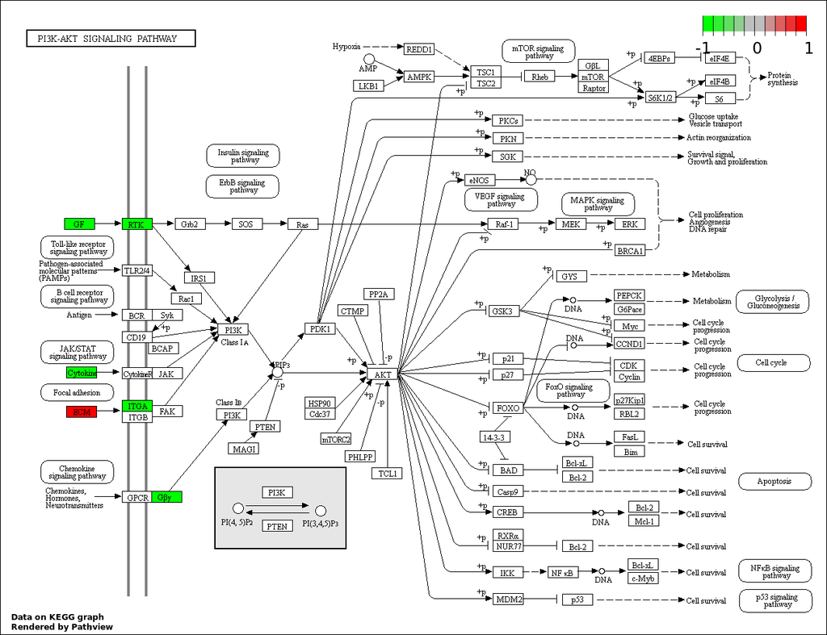

```r
knitr::include_graphics(filename)
```

```r
filename <- paste0(plotdir, "Enriched_GO.png")
sigident.func::plot_enriched_barplot(
  enrichmentobj = enr_analysis$go,
  type = "GO",
  filename = filename
)
```

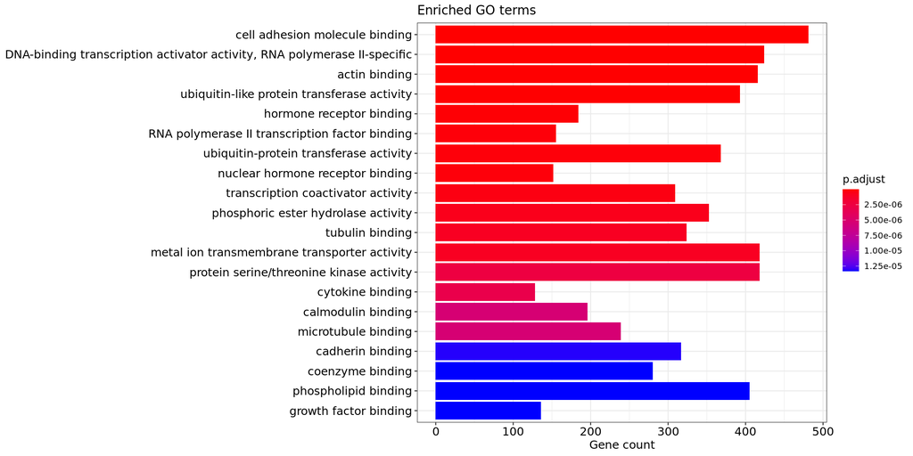

```r
knitr::include_graphics(filename)
```

```r
filename <- paste0(plotdir, "Enriched_KEGG.png")
sigident.func::plot_enriched_barplot(
  enrichmentobj = enr_analysis$kegg,
  type = "KEGG",
  filename = filename
)
```

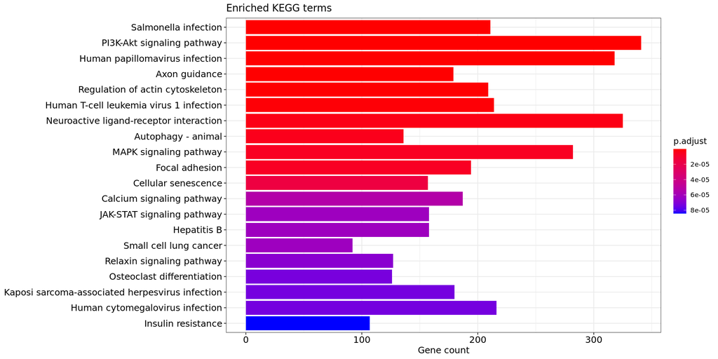

```r
knitr::include_graphics(filename)
```

```r
rm(bods, enr_analysis, enr_fitlm, enr_fitlm_topgo, enr_fitlm_topkegg,
   enr_topgo, enr_topkegg, gene.idtype.bods, korg, cpd.simtypes,
   deg_entrez, gene.idtype.list, ht_colors, mergedset)
gc()
```

# Identification of diagnostic signatures

A common task regarding gene expression data is to distinguish between different groups or subtypes. In order to train a multi-gene classifier, a large amount of expression data is required. Due to the imbalance of features (p) versus observations (n), the application of an appropriate method is needed.  
The lasso regression and elastic net regularization are generalized linear models which are powerful and versatile methods for feature selection and are well suited in order to analyse genomic data with p >> n.  
Therefore, we implemented the elastic net regularization method for the identification of a diagnostic multi-gene signature.

## Split data into training and test dataset

A statistical prediction model is usually trained on 70%-80% percent of the present data. `create_training_test_split` randomly splits the merged dataset into a training and a test set with the former defined value `split` regarding to a balanced distribution of the groups (here diagnosis). For reproducibility, a seed must be set.

```r
training_list <- sigident::create_training_test_split(
  diagnosis = diagnosis,
  mergeset = mergeset,
  split = split,
  seed = seed
)
```

## Lasso regression

Regularization requires the selection of a tuning parameter (lambda) that determines the strength of regularization. The function `signature` performs an `nfolds` cross-validation to select the best lambda and additionally builds the predictive model. `seed` is again set for reproducibility. The plot depicts the mean squared error as the criteron for the 10-fold cross-validation and shows the optimal values of lambda and the appropriate number of selected features (genes) above the plot. The left dashed vertical line represents the log of the optimal value of lambda (‘lambda min’), which results in the lowest prediction error and giving the most accurate model. The right dashed vertical line indicates the log of the lambda value resulting in a model with the smallest number of included variables but also lies within one standard error of the optimal value of lambda (‘lambda 1se’).  
Furthermore, a ROC curve is plotted to visualize the performance measurement of the model.

```r
diagnostic_lasso <- sigident::signature(
  traininglist = training_list,
  type = "lasso",
  nfolds = nfolds,
  seed = seed
)
filename <- paste0(plotdir, "CV_lasso.png")
sigident::plot_cvplot(cv_obj = diagnostic_lasso$fit_cv,
                      filename = filename)
```

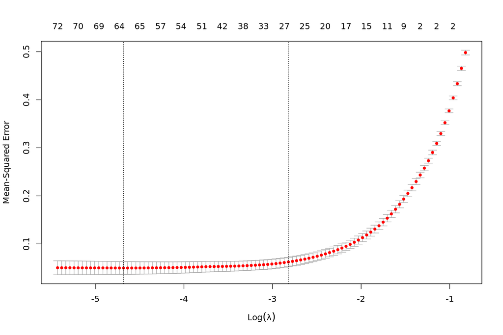

```r
knitr::include_graphics(filename)
```

```r
filename <- paste0(plotdir, "ROC_Lasso.min.png")
sigident::plot_rocplot(roc = diagnostic_lasso$roc_min,
                       filename = filename)
```

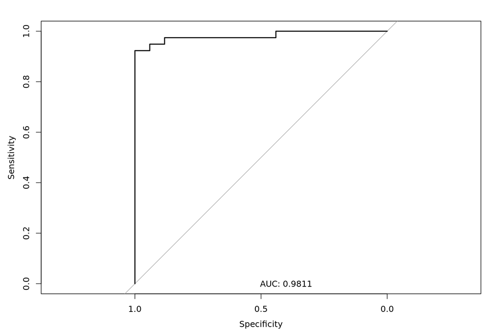

```r
knitr::include_graphics(filename)
```

```r
filename <- paste0(plotdir, "ROC_Lasso.1se.png")
sigident::plot_rocplot(roc = diagnostic_lasso$roc_1se,
                       filename = filename)
```

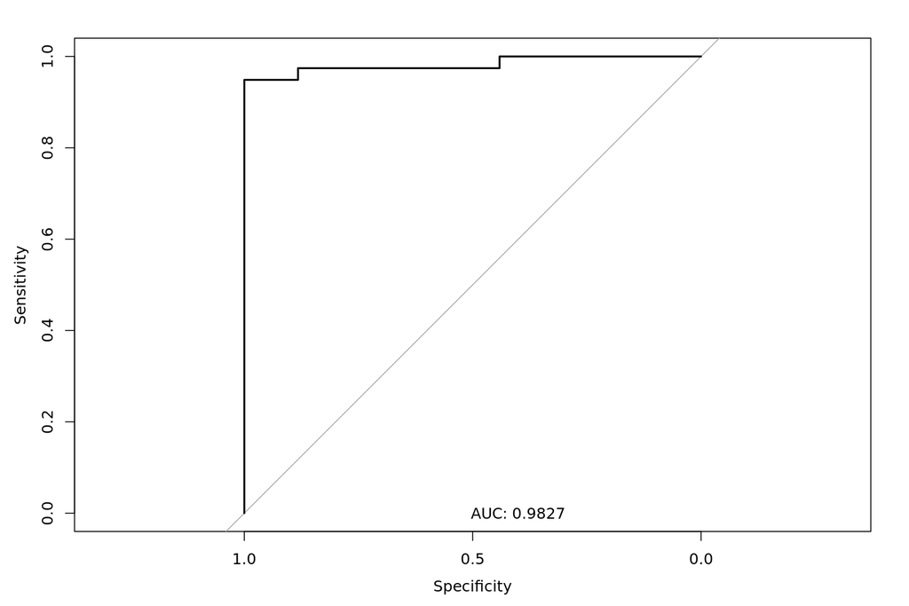

```r
knitr::include_graphics(filename)
```

## Elastic net regression

The elastic net is a mixture of lasso and ridge regularization to shrink coefficients (like in ridge regression) and to set some coefficients to zero (as in lasso). Therefore, the mixing parameter alpha needs to be determined as value between 1 (for lasso) and 0 (for ridge). A grid search for calculating optimal alpha and lambda can be conducted (as it is done next) but might take much computing capacity, hence we propose setting alpha manually to 0.9.

```r
diagnostic_elasticnet <- sigident::signature(
  traininglist = training_list,
  type = "elastic",
  alpha = 0.9,
  nfolds = nfolds,
  seed = seed
)
filename <- paste0(plotdir, "CV_elasticNet.png")
sigident::plot_cvplot(cv_obj = diagnostic_elasticnet$fit_cv,
                      filename = filename)
```

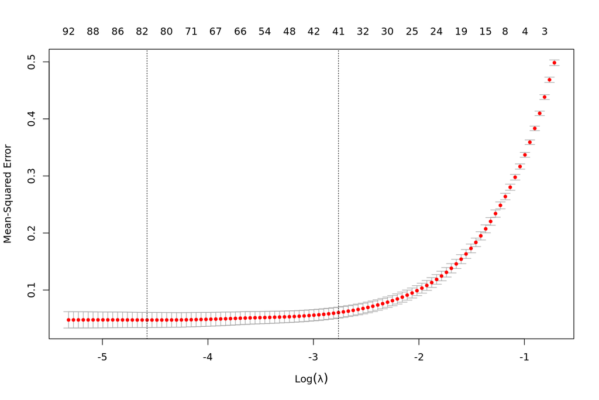

```r
knitr::include_graphics(filename)
```

```r
filename <- paste0(plotdir, "ROC_elasticNet.min.png")
sigident::plot_rocplot(roc = diagnostic_elasticnet$roc_min,
                       filename = filename)
```

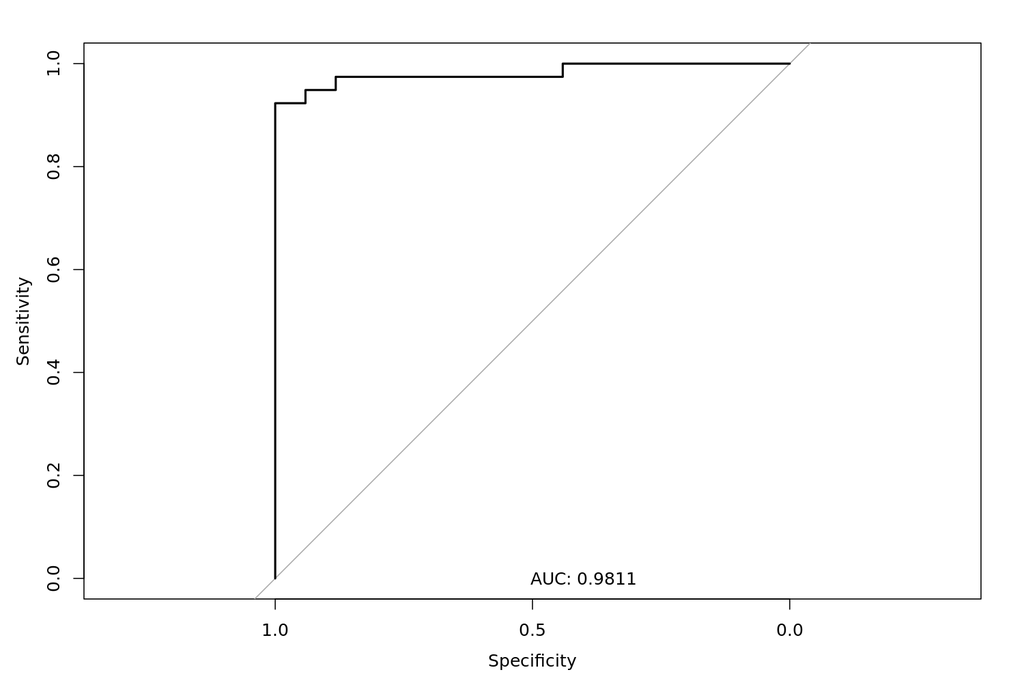

```r
knitr::include_graphics(filename)
```

```r
filename <- paste0(plotdir, "ROC_elasticNet.1se.png")
sigident::plot_rocplot(roc = diagnostic_elasticnet$roc_1se,
                       filename = filename)
```

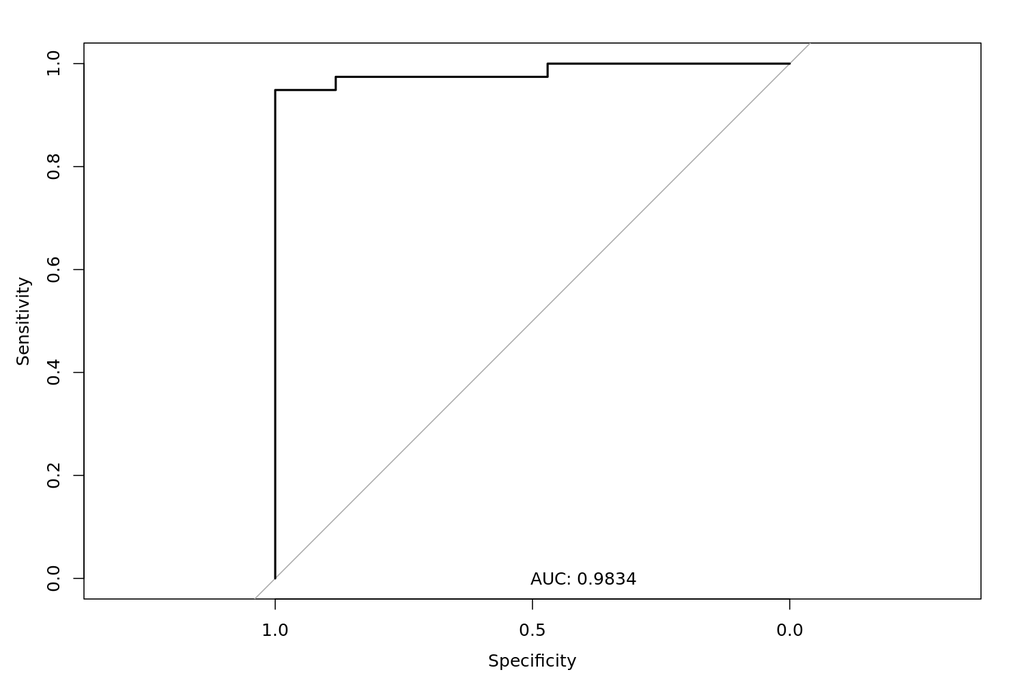

```r
knitr::include_graphics(filename)
```

## Gridsearch to find alpha and lambda

Setting `type = "elasitnet_grid"` of the function `signature` conducts a grid search calculating a pair of alpha and lambda for the ‘glmnet’-method, that minimizes the CV error, using the R package [caret](https://cran.r-project.org/web/packages/caret/index.html).

```r
diagnostic_glmgrid <- sigident::signature(
  traininglist = training_list,
  type = "elasitnet_grid",
  nfolds = nfolds,
  seed = seed
)
# plot model of gridsearch
filename <- paste0(plotdir, "Gridsearch_model.png")
sigident::plot_grid_model_plot(model = diagnostic_glmgrid$caret_train,
                               filename = filename)
```

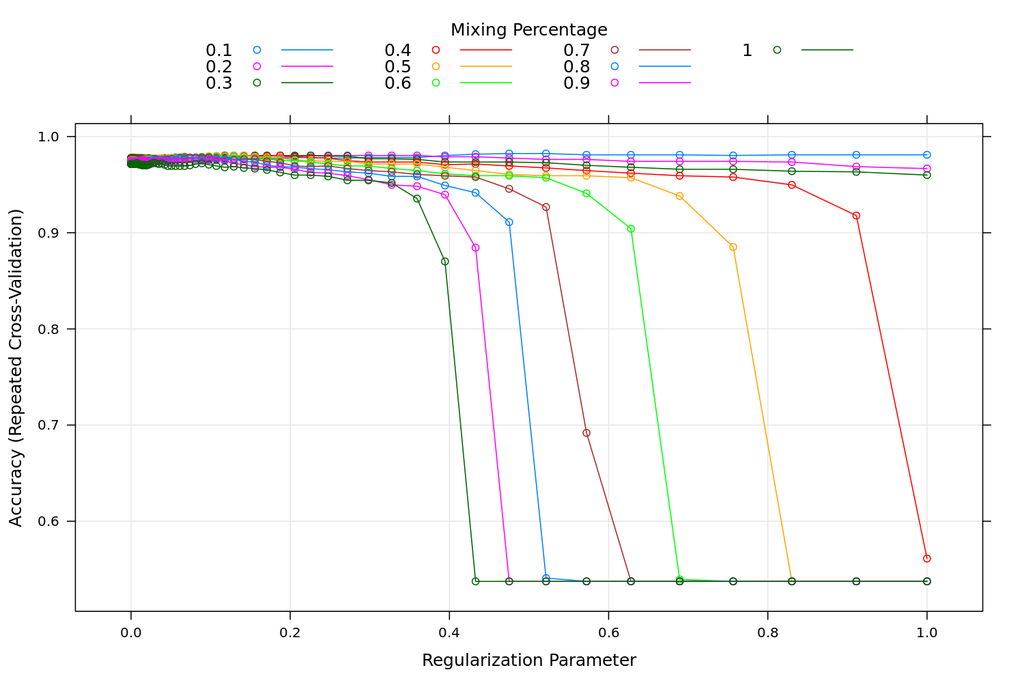

```r
knitr::include_graphics(filename)
```

```r
# plot variable importance of gridsearch
filename <- paste0(plotdir, "Elasticnet_Gridsearch_var_imp.png")
sigident::plot_grid_varimp_plot(model = diagnostic_glmgrid$caret_train,
                                filename = filename)
```

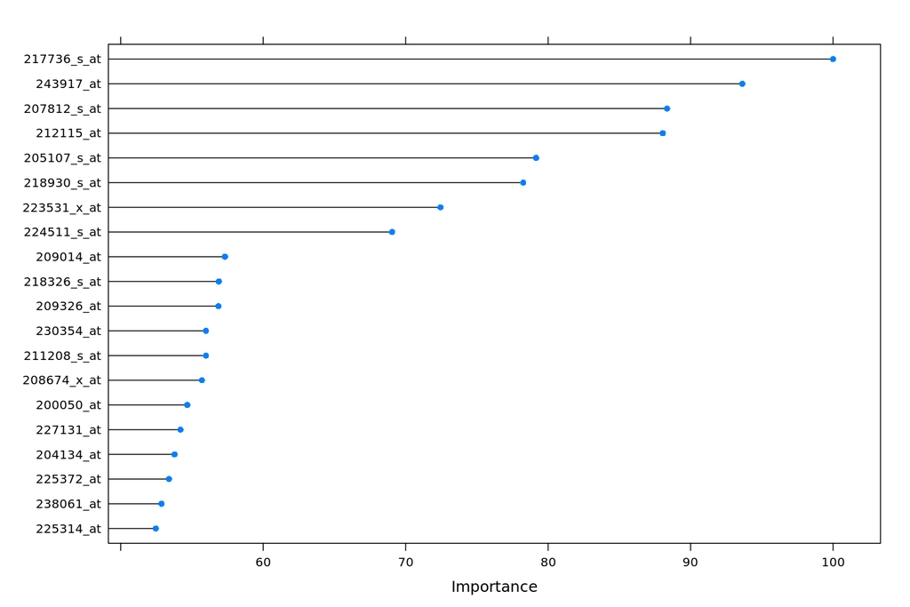

```r
knitr::include_graphics(filename)
```

```r
# create roc plot
filename <- paste0(plotdir, "ROC_elasticNet.grid.png")
sigident::plot_rocplot(roc = diagnostic_glmgrid$roc_elasticnet,
                       filename = filename)
```

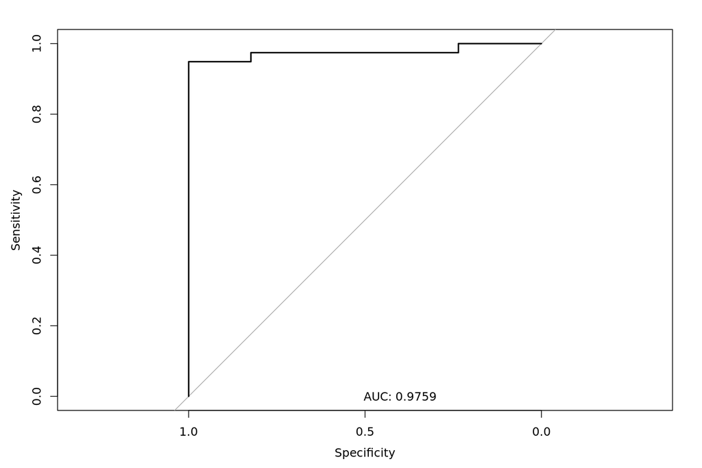

```r
knitr::include_graphics(filename)
```

## Analysis of diagnostic models

### Comparing model performance

These models can be included into a list and the performance metrices for classification can then be printed using the function `compare_diagnostic_models()`. This list includes all information of the respective models, which can be accessed by the following structure.

```r
diagnostic_models <- list(
  "lasso" = list(
    "CV" = diagnostic_lasso$fit_cv,
    "min" = list("model" = diagnostic_lasso$lambda_min,
                 "confmat" = diagnostic_lasso$confmat_min,
                 "prediction" = diagnostic_lasso$predicted_min,
                 "auc" = as.numeric(diagnostic_lasso$roc_min$auc)
                 ),
    "1se" = list("model" = diagnostic_lasso$lambda_1se,
                 "confmat" = diagnostic_lasso$confmat_1se,
                 "prediction" = diagnostic_lasso$predicted_1se,
                 "auc" = as.numeric(diagnostic_lasso$roc_1se$auc)
                 )
  ),
  "elasticnet" = list(
    "CV" = diagnostic_elasticnet$fit_cv,
    "min" = list("model" = diagnostic_elasticnet$lambda_min,
                 "confmat" = diagnostic_elasticnet$confmat_min,
                 "prediction" = diagnostic_elasticnet$predicted_min,
                 "auc" = as.numeric(diagnostic_elasticnet$roc_min$auc)
                 ),
    "1se" = list("model" = diagnostic_elasticnet$lambda_1se,
                 "confmat" = diagnostic_elasticnet$confmat_1se,
                 "prediction" = diagnostic_elasticnet$predicted_1se,
                 "auc" = as.numeric(diagnostic_elasticnet$roc_1se$auc)
                 )
  ),
  "elasitnet_grid" = list(
    "CV" = diagnostic_glmgrid$caret_train,
    "model" = diagnostic_glmgrid$elasticnet_auto,
    "confmat" = diagnostic_glmgrid$confmat_elasticnet,
    "prediction" = diagnostic_elasticnet$predicted_elasticnet,
    "auc" = as.numeric(diagnostic_glmgrid$roc_elasticnet$auc)
    )
)
```

```r
knitr::kable(
  sigident::compare_diagnostic_models(diagnostic_models)
)
```

| Model | AUC |
| --- | --- |
| lasso.min | 0.981 |
| lasso.1se | 0.983 |
| elasticnet.min | 0.981 |
| elasticnet.1se | 0.983 |
| elasitnet_grid | 0.976 |

```r
rm(diagnostic_glmgrid, diagnostic_elasticnet, diagnostic_lasso,
   training_list)
gc()
```

### Extract lambda values

A function `get_diagnostic_lambda_values` was designed, to extract the results of the cross validation.

```r
knitr::kable(
  sigident::get_diagnostic_lambda_values(diagnostic_models)
)
```

| Model | Lambda min | Lambda 1se |
| --- | --- | --- |
| lasso | 0.009260 | 0.059521 |
| elasticnet | 0.010288 | 0.063129 |
| elasitnet_grid (best tune, alpha, lambda) | 0.100000 | 0.521401 |

### Model performance measurements

Additionally, the confusion matrix and the calculated performance metrics can be printed out for each model.

#### Lasso (min)

```r
diagnostic_models$lasso$min$confmat
```

```
#> Confusion Matrix and Statistics
#>
#>           Reference
#> Prediction  0  1
#>          0 32  2
#>          1  2 37
#>
#>                Accuracy : 0.9452
#>                  95% CI : (0.8656, 0.9849)
#>     No Information Rate : 0.5342
#>     P-Value [Acc > NIR] : 8.964e-15
#>
#>                   Kappa : 0.8899
#>
#>  Mcnemar's Test P-Value : 1
#>
#>             Sensitivity : 0.9487
#>             Specificity : 0.9412
#>          Pos Pred Value : 0.9487
#>          Neg Pred Value : 0.9412
#>              Prevalence : 0.5342
#>          Detection Rate : 0.5068
#>    Detection Prevalence : 0.5342
#>       Balanced Accuracy : 0.9449
#>
#>        'Positive' Class : 1
#>
```

#### Lasso (1se)

```r
diagnostic_models$lasso[["1se"]]$confmat
```

```
#> Confusion Matrix and Statistics
#>
#>           Reference
#> Prediction  0  1
#>          0 34  2
#>          1  0 37
#>
#>                Accuracy : 0.9726
#>                  95% CI : (0.9045, 0.9967)
#>     No Information Rate : 0.5342
#>     P-Value [Acc > NIR] : <2e-16
#>
#>                   Kappa : 0.9452
#>
#>  Mcnemar's Test P-Value : 0.4795
#>
#>             Sensitivity : 0.9487
#>             Specificity : 1.0000
#>          Pos Pred Value : 1.0000
#>          Neg Pred Value : 0.9444
#>              Prevalence : 0.5342
#>          Detection Rate : 0.5068
#>    Detection Prevalence : 0.5068
#>       Balanced Accuracy : 0.9744
#>
#>        'Positive' Class : 1
#>
```

#### Elastic (min)

```r
diagnostic_models$elasticnet$min$confmat
```

```
#> Confusion Matrix and Statistics
#>
#>           Reference
#> Prediction  0  1
#>          0 32  2
#>          1  2 37
#>
#>                Accuracy : 0.9452
#>                  95% CI : (0.8656, 0.9849)
#>     No Information Rate : 0.5342
#>     P-Value [Acc > NIR] : 8.964e-15
#>
#>                   Kappa : 0.8899
#>
#>  Mcnemar's Test P-Value : 1
#>
#>             Sensitivity : 0.9487
#>             Specificity : 0.9412
#>          Pos Pred Value : 0.9487
#>          Neg Pred Value : 0.9412
#>              Prevalence : 0.5342
#>          Detection Rate : 0.5068
#>    Detection Prevalence : 0.5342
#>       Balanced Accuracy : 0.9449
#>
#>        'Positive' Class : 1
#>
```

#### Elastic (1se)

```r
diagnostic_models$elasticnet[["1se"]]$confmat
```

```
#> Confusion Matrix and Statistics
#>
#>           Reference
#> Prediction  0  1
#>          0 34  2
#>          1  0 37
#>
#>                Accuracy : 0.9726
#>                  95% CI : (0.9045, 0.9967)
#>     No Information Rate : 0.5342
#>     P-Value [Acc > NIR] : <2e-16
#>
#>                   Kappa : 0.9452
#>
#>  Mcnemar's Test P-Value : 0.4795
#>
#>             Sensitivity : 0.9487
#>             Specificity : 1.0000
#>          Pos Pred Value : 1.0000
#>          Neg Pred Value : 0.9444
#>              Prevalence : 0.5342
#>          Detection Rate : 0.5068
#>    Detection Prevalence : 0.5068
#>       Balanced Accuracy : 0.9744
#>
#>        'Positive' Class : 1
#>
```

#### Elastic net (grid search)

```r
diagnostic_models$grid$confmat
```

[output not shown]

### Export selected IDs for each model

The following function enables the extraction of the selected genes (Affy-IDs) for each model as csv file.

```r
signaturegenes <- sigident::gene_map_sig(
  mergeset = mergeset,
  model = diagnostic_models$lasso$min$model
)
data.table::fwrite(signaturegenes,
                   paste0(csvdir, "signaturegenes_lasso_min.csv"))
```

```r
signaturegenes <- sigident::gene_map_sig(
  mergeset = mergeset,
  model = diagnostic_models$lasso[["1se"]]$model
)
data.table::fwrite(signaturegenes,
                   paste0(csvdir, "signaturegenes_lasso_1se.csv"))
```

```r
signaturegenes <- sigident::gene_map_sig(
  mergeset = mergeset,
  model = diagnostic_models$elasticnet$min$model
)
data.table::fwrite(signaturegenes,
                   paste0(csvdir, "signaturegenes_elasticnet_min.csv"))
```

```r
signaturegenes <- sigident::gene_map_sig(
  mergeset = mergeset,
  model = diagnostic_models$elasticnet[["1se"]]$model
)
data.table::fwrite(signaturegenes,
                   paste0(csvdir, "signaturegenes_elasticnet_1se.csv"))
```

```r
rm(signaturegenes)
gc()
```

## Validation of diagnostic signatures

The validation of diagnostic signatures is conducted using the independent expression datasets of the studies “GSE30219”, “GSE33356” and “GSE102287”. We therefore need to create a list, holding meta information about the respective studies.

You have to create a list that contains specifications of the validation studeis. The object must be named. The list structure is as follows:  
* `studyname`: the GEO id of the validation study  
+ `setid`: the index of the provided GEO set to be used  
+ `targetcolname`: the name of the phenoData column containing the target-variable  
+ `controllevelname`: the level name of the controls of the column, specified in `targetcolname`  
+ `targetlevelname`: the level name of the subjects of interest in `targetcolname`

```r
validationstudylist <- list(
  "GSE30219" = list(
    setid = 1,
    targetcolname = "source_name_ch1",
    controllevelname = "Non Tumoral Lung",
    targetlevelname = "Lung Tumour"
  ),
  "GSE33356" = list(
    setid = 1,
    targetcolname = "characteristics_ch1",
    controllevelname = "tissue: paired normal adjacent",
    targetlevelname = "tissue: lung cancer"
  ),
  "GSE102287" = list(
    setid = 2,
    targetcolname = "characteristics_ch1.6",
    controllevelname = "tumor_normal status: N",
    targetlevelname = "tumor_normal status: T"
  )
)
```

All models can be provided via the argument ‘model’ to the function `sigident::validate_diagnostic_signatures` using the previously created list `diagnostic_models`.

To perform the validation of the diagnostic signatures, simply run the function `sigident::validate_diagnostic_signatures` with the specified `validationstudylist`.

```r
validation_results <- sigident::validate_diagnostic_signatures(
  validationstudylist = validationstudylist,
  models = diagnostic_models,
  genes = genes,
  idtype = idtype,
  datadir = datadir
)
```

#### Lasso (min)

```r
validation_results[["GSE30219"]]$lasso$min$confmat
```

```
#> Confusion Matrix and Statistics
#>
#>           Reference
#> Prediction   0   1
#>          0  13  32
#>          1   1 261
#>
#>                Accuracy : 0.8925
#>                  95% CI : (0.8524, 0.9248)
#>     No Information Rate : 0.9544
#>     P-Value [Acc > NIR] : 1
#>
#>                   Kappa : 0.3989
#>
#>  Mcnemar's Test P-Value : 1.767e-07
#>
#>             Sensitivity : 0.8908
#>             Specificity : 0.9286
#>          Pos Pred Value : 0.9962
#>          Neg Pred Value : 0.2889
#>              Prevalence : 0.9544
#>          Detection Rate : 0.8502
#>    Detection Prevalence : 0.8534
#>       Balanced Accuracy : 0.9097
#>
#>        'Positive' Class : 1
#>
```

```r
# create roc plot
filename <- paste0(plotdir, "ROC_validation_GSE30219_lasso_min.png")
sigident::plot_rocplot(roc = validation_results[["GSE30219"]]$lasso$min$roc,
                       filename = filename)
```

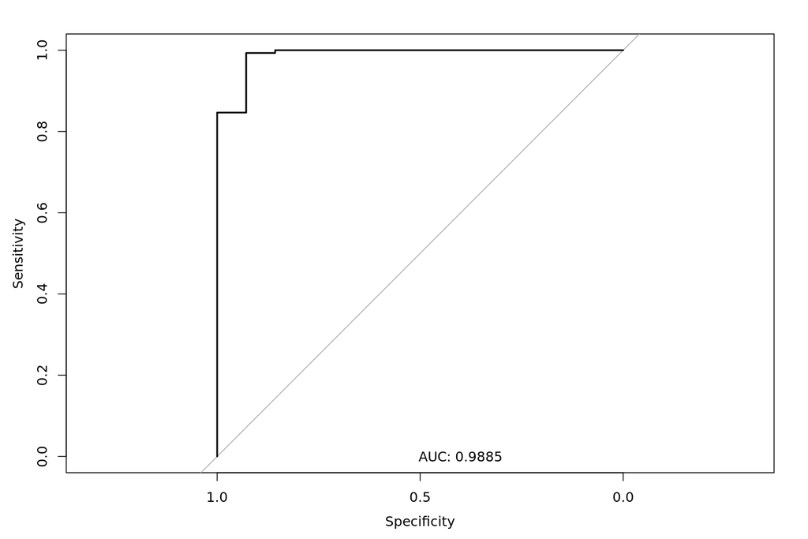

```r
knitr::include_graphics(filename)
```

#### Lasso (1se)

```r
validation_results[["GSE30219"]]$lasso[["1se"]]$confmat
```

```
#> Confusion Matrix and Statistics
#>
#>           Reference
#> Prediction   0   1
#>          0  13   4
#>          1   1 289
#>
#>                Accuracy : 0.9837
#>                  95% CI : (0.9624, 0.9947)
#>     No Information Rate : 0.9544
#>     P-Value [Acc > NIR] : 0.004794
#>
#>                   Kappa : 0.8302
#>
#>  Mcnemar's Test P-Value : 0.371093
#>
#>             Sensitivity : 0.9863
#>             Specificity : 0.9286
#>          Pos Pred Value : 0.9966
#>          Neg Pred Value : 0.7647
#>              Prevalence : 0.9544
#>          Detection Rate : 0.9414
#>    Detection Prevalence : 0.9446
#>       Balanced Accuracy : 0.9575
#>
#>        'Positive' Class : 1
#>
```

```r
# create roc plot
filename <- paste0(plotdir, "ROC_validation_GSE30219_lasso_1se.png")
sigident::plot_rocplot(roc = validation_results[["GSE30219"]]$lasso[["1se"]]$roc,
                       filename = filename)
```

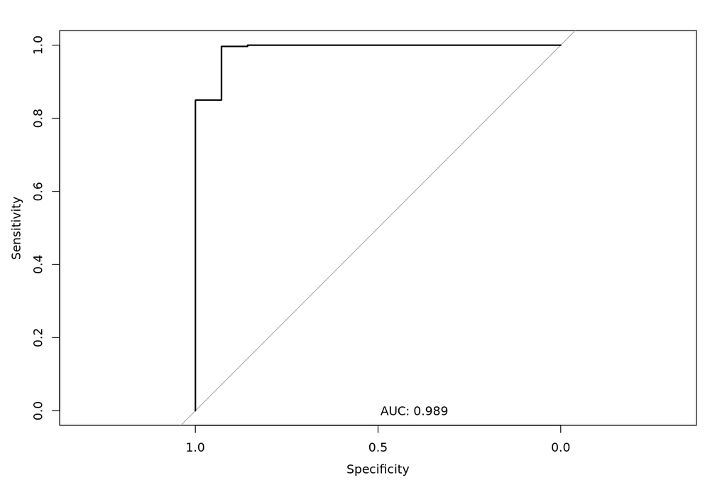

```r
knitr::include_graphics(filename)
```

#### Elastic (min)

```r
validation_results[["GSE30219"]]$elasticnet$min$confmat
```

```
#> Confusion Matrix and Statistics
#>
#>           Reference
#> Prediction   0   1
#>          0  13  23
#>          1   1 270
#>
#>                Accuracy : 0.9218
#>                  95% CI : (0.8859, 0.9493)
#>     No Information Rate : 0.9544
#>     P-Value [Acc > NIR] : 0.9959
#>
#>                   Kappa : 0.4863
#>
#>  Mcnemar's Test P-Value : 1.814e-05
#>
#>             Sensitivity : 0.9215
#>             Specificity : 0.9286
#>          Pos Pred Value : 0.9963
#>          Neg Pred Value : 0.3611
#>              Prevalence : 0.9544
#>          Detection Rate : 0.8795
#>    Detection Prevalence : 0.8827
#>       Balanced Accuracy : 0.9250
#>
#>        'Positive' Class : 1
#>
```

```r
# create roc plot
filename <- paste0(plotdir, "ROC_validation_GSE30219_elasticnet_min.png")
sigident::plot_rocplot(roc = validation_results[["GSE30219"]]$elasticnet$min$roc,
                       filename = filename)
```

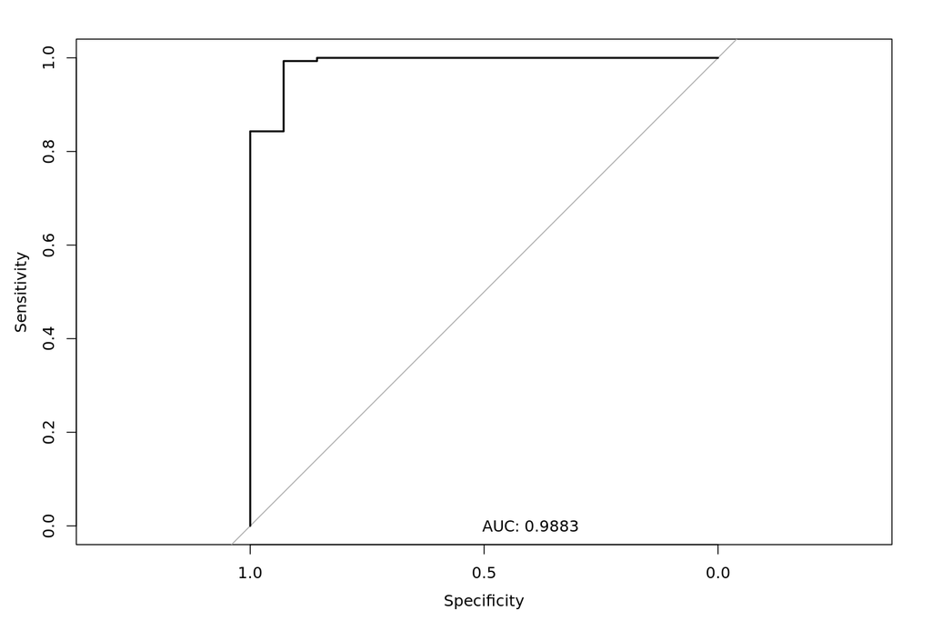

```r
knitr::include_graphics(filename)
```

#### Elastic (1se)

```r
validation_results[["GSE30219"]]$elasticnet[["1se"]]$confmat
```

```
#> Confusion Matrix and Statistics
#>
#>           Reference
#> Prediction   0   1
#>          0  13   4
#>          1   1 289
#>
#>                Accuracy : 0.9837
#>                  95% CI : (0.9624, 0.9947)
#>     No Information Rate : 0.9544
#>     P-Value [Acc > NIR] : 0.004794
#>
#>                   Kappa : 0.8302
#>
#>  Mcnemar's Test P-Value : 0.371093
#>
#>             Sensitivity : 0.9863
#>             Specificity : 0.9286
#>          Pos Pred Value : 0.9966
#>          Neg Pred Value : 0.7647
#>              Prevalence : 0.9544
#>          Detection Rate : 0.9414
#>    Detection Prevalence : 0.9446
#>       Balanced Accuracy : 0.9575
#>
#>        'Positive' Class : 1
#>
```

```r
# create roc plot
filename <- paste0(plotdir, "ROC_validation_GSE30219_elasticnet_1se.png")
sigident::plot_rocplot(roc = validation_results[["GSE30219"]]$elasticnet[["1se"]]$roc,
                       filename = filename)
```

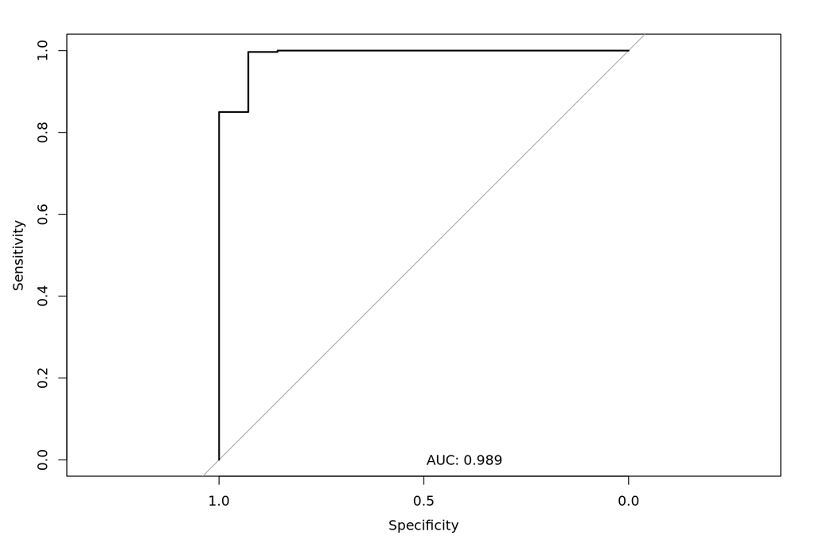

```r
knitr::include_graphics(filename)
```

```r
validation_results[["GSE30219"]] <- NULL
gc()
```

### GSE33356

#### Lasso (min)

```r
validation_results[["GSE33356"]]$lasso$min$confmat
```

```
#> Confusion Matrix and Statistics
#>
#>           Reference
#> Prediction  0  1
#>          0 60  6
#>          1  0 54
#>
#>                Accuracy : 0.95
#>                  95% CI : (0.8943, 0.9814)
#>     No Information Rate : 0.5
#>     P-Value [Acc > NIR] : < 2e-16
#>
#>                   Kappa : 0.9
#>
#>  Mcnemar's Test P-Value : 0.04123
#>
#>             Sensitivity : 0.9000
#>             Specificity : 1.0000
#>          Pos Pred Value : 1.0000
#>          Neg Pred Value : 0.9091
#>              Prevalence : 0.5000
#>          Detection Rate : 0.4500
#>    Detection Prevalence : 0.4500
#>       Balanced Accuracy : 0.9500
#>
#>        'Positive' Class : 1
#>
```

```r
# create roc plot
filename <- paste0(plotdir, "ROC_validation_GSE33356_lasso_min.png")
sigident::plot_rocplot(roc = validation_results[["GSE33356"]]$lasso$min$roc,
                       filename = filename)
```

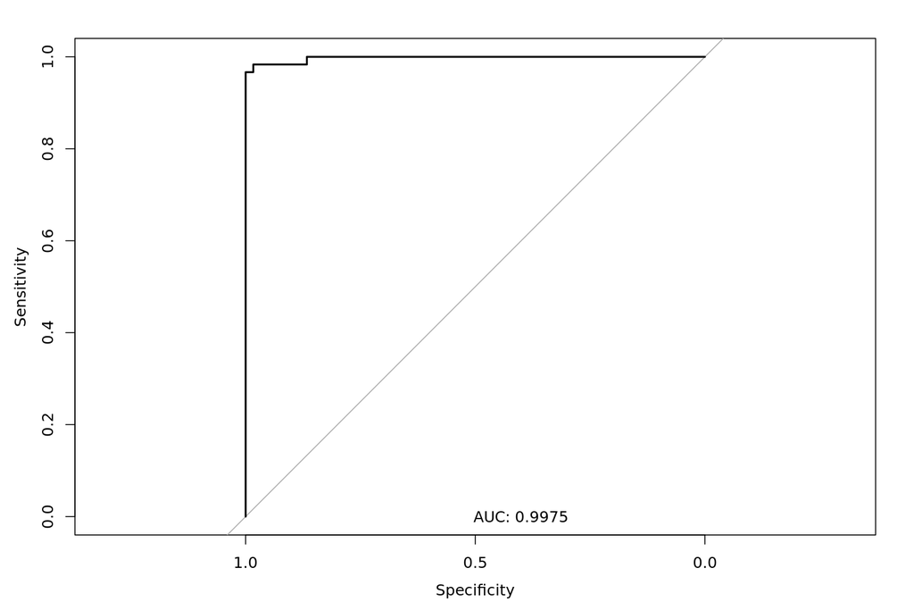

```r
knitr::include_graphics(filename)
```

#### Lasso (1se)

```r
validation_results[["GSE33356"]]$lasso[["1se"]]$confmat
```

```
#> Confusion Matrix and Statistics
#>
#>           Reference
#> Prediction  0  1
#>          0 59  3
#>          1  1 57
#>
#>                Accuracy : 0.9667
#>                  95% CI : (0.9169, 0.9908)
#>     No Information Rate : 0.5
#>     P-Value [Acc > NIR] : <2e-16
#>
#>                   Kappa : 0.9333
#>
#>  Mcnemar's Test P-Value : 0.6171
#>
#>             Sensitivity : 0.9500
#>             Specificity : 0.9833
#>          Pos Pred Value : 0.9828
#>          Neg Pred Value : 0.9516
#>              Prevalence : 0.5000
#>          Detection Rate : 0.4750
#>    Detection Prevalence : 0.4833
#>       Balanced Accuracy : 0.9667
#>
#>        'Positive' Class : 1
#>
```

```r
# create roc plot
filename <- paste0(plotdir, "ROC_validation_GSE33356_lasso_1se.png")
sigident::plot_rocplot(roc = validation_results[["GSE33356"]]$lasso[["1se"]]$roc,
                       filename = filename)
```

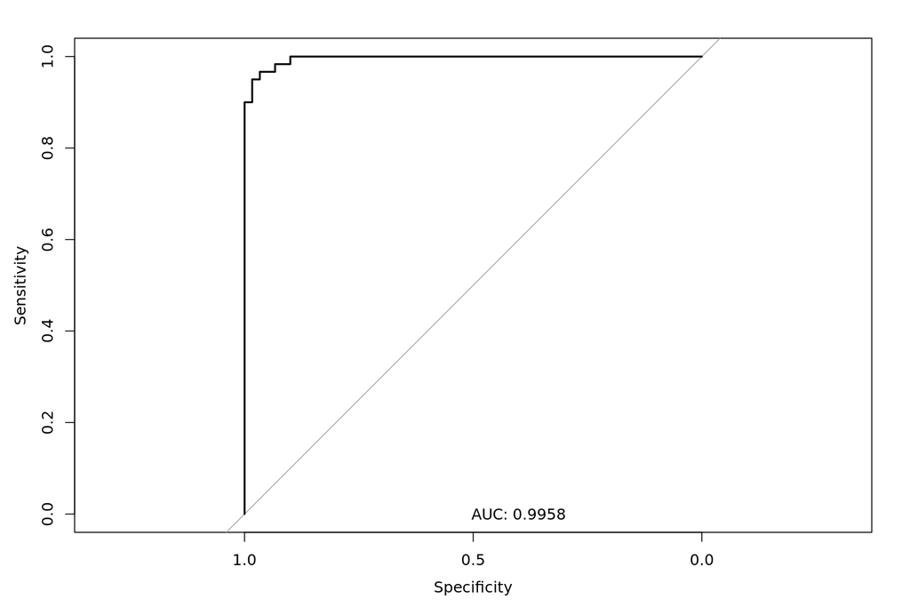

```r
knitr::include_graphics(filename)
```

#### Elastic (min)

```r
validation_results[["GSE33356"]]$elasticnet$min$confmat
```

```
#> Confusion Matrix and Statistics
#>
#>           Reference
#> Prediction  0  1
#>          0 60  7
#>          1  0 53
#>
#>                Accuracy : 0.9417
#>                  95% CI : (0.8835, 0.9762)
#>     No Information Rate : 0.5
#>     P-Value [Acc > NIR] : < 2e-16
#>
#>                   Kappa : 0.8833
#>
#>  Mcnemar's Test P-Value : 0.02334
#>
#>             Sensitivity : 0.8833
#>             Specificity : 1.0000
#>          Pos Pred Value : 1.0000
#>          Neg Pred Value : 0.8955
#>              Prevalence : 0.5000
#>          Detection Rate : 0.4417
#>    Detection Prevalence : 0.4417
#>       Balanced Accuracy : 0.9417
#>
#>        'Positive' Class : 1
#>
```

```r
# create roc plot
filename <- paste0(plotdir, "ROC_validation_GSE33356_elasticnet_min.png")
sigident::plot_rocplot(roc = validation_results[["GSE33356"]]$elasticnet$min$roc,
                       filename = filename)
```

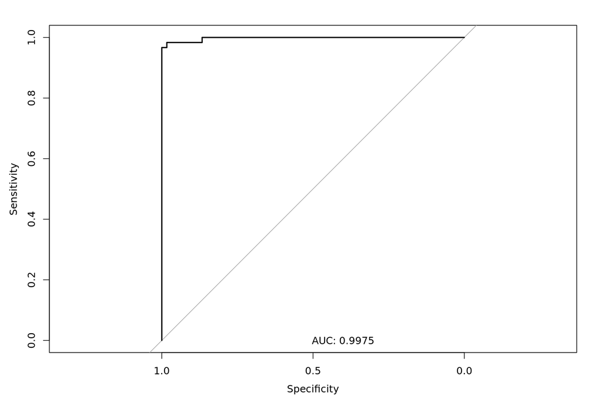

```r
knitr::include_graphics(filename)
```

#### Elastic (1se)

```r
validation_results[["GSE33356"]]$elasticnet[["1se"]]$confmat
```

```
#> Confusion Matrix and Statistics
#>
#>           Reference
#> Prediction  0  1
#>          0 59  3
#>          1  1 57
#>
#>                Accuracy : 0.9667
#>                  95% CI : (0.9169, 0.9908)
#>     No Information Rate : 0.5
#>     P-Value [Acc > NIR] : <2e-16
#>
#>                   Kappa : 0.9333
#>
#>  Mcnemar's Test P-Value : 0.6171
#>
#>             Sensitivity : 0.9500
#>             Specificity : 0.9833
#>          Pos Pred Value : 0.9828
#>          Neg Pred Value : 0.9516
#>              Prevalence : 0.5000
#>          Detection Rate : 0.4750
#>    Detection Prevalence : 0.4833
#>       Balanced Accuracy : 0.9667
#>
#>        'Positive' Class : 1
#>
```

```r
# create roc plot
filename <- paste0(plotdir, "ROC_validation_GSE33356_elasticnet_1se.png")
sigident::plot_rocplot(roc = validation_results[["GSE33356"]]$elasticnet[["1se"]]$roc,
                       filename = filename)
```

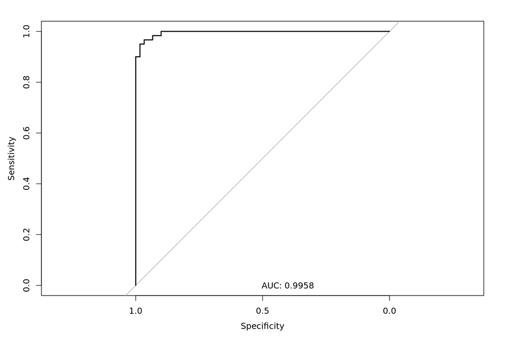

```r
knitr::include_graphics(filename)
```

```r
validation_results[["GSE33356"]] <- NULL
gc()
```

### GSE102287

#### Lasso (min)

```r
validation_results[["GSE102287"]]$lasso$min$confmat
```

```
#> Confusion Matrix and Statistics
#>
#>           Reference
#> Prediction  0  1
#>          0 32  1
#>          1  2 31
#>
#>                Accuracy : 0.9545
#>                  95% CI : (0.8729, 0.9905)
#>     No Information Rate : 0.5152
#>     P-Value [Acc > NIR] : 3.899e-15
#>
#>                   Kappa : 0.9091
#>
#>  Mcnemar's Test P-Value : 1
#>
#>             Sensitivity : 0.9688
#>             Specificity : 0.9412
#>          Pos Pred Value : 0.9394
#>          Neg Pred Value : 0.9697
#>              Prevalence : 0.4848
#>          Detection Rate : 0.4697
#>    Detection Prevalence : 0.5000
#>       Balanced Accuracy : 0.9550
#>
#>        'Positive' Class : 1
#>
```

```r
# create roc plot
filename <- paste0(plotdir, "ROC_validation_GSE102287_lasso_min.png")
sigident::plot_rocplot(roc = validation_results[["GSE102287"]]$lasso$min$roc,
                       filename = filename)
```

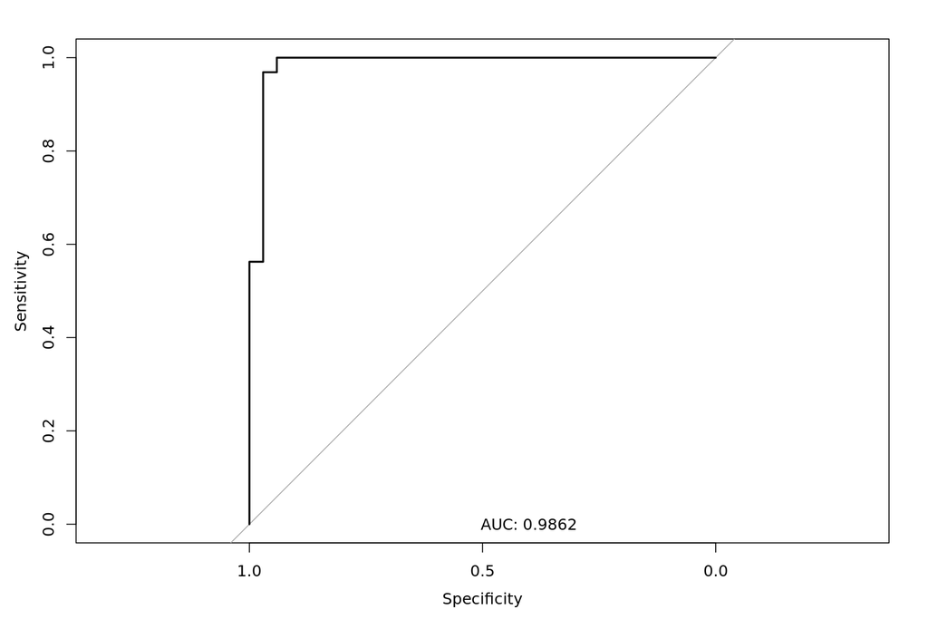

```r
knitr::include_graphics(filename)
```

#### Lasso (1se)

```r
validation_results[["GSE102287"]]$lasso[["1se"]]$confmat
```

```
#> Confusion Matrix and Statistics
#>
#>           Reference
#> Prediction  0  1
#>          0 33  1
#>          1  1 31
#>
#>                Accuracy : 0.9697
#>                  95% CI : (0.8948, 0.9963)
#>     No Information Rate : 0.5152
#>     P-Value [Acc > NIR] : <2e-16
#>
#>                   Kappa : 0.9393
#>
#>  Mcnemar's Test P-Value : 1
#>
#>             Sensitivity : 0.9688
#>             Specificity : 0.9706
#>          Pos Pred Value : 0.9688
#>          Neg Pred Value : 0.9706
#>              Prevalence : 0.4848
#>          Detection Rate : 0.4697
#>    Detection Prevalence : 0.4848
#>       Balanced Accuracy : 0.9697
#>
#>        'Positive' Class : 1
#>
```

```r
# create roc plot
filename <- paste0(plotdir, "ROC_validation_GSE102287_lasso_1se.png")
sigident::plot_rocplot(roc = validation_results[["GSE102287"]]$lasso[["1se"]]$roc,
                       filename = filename)
```

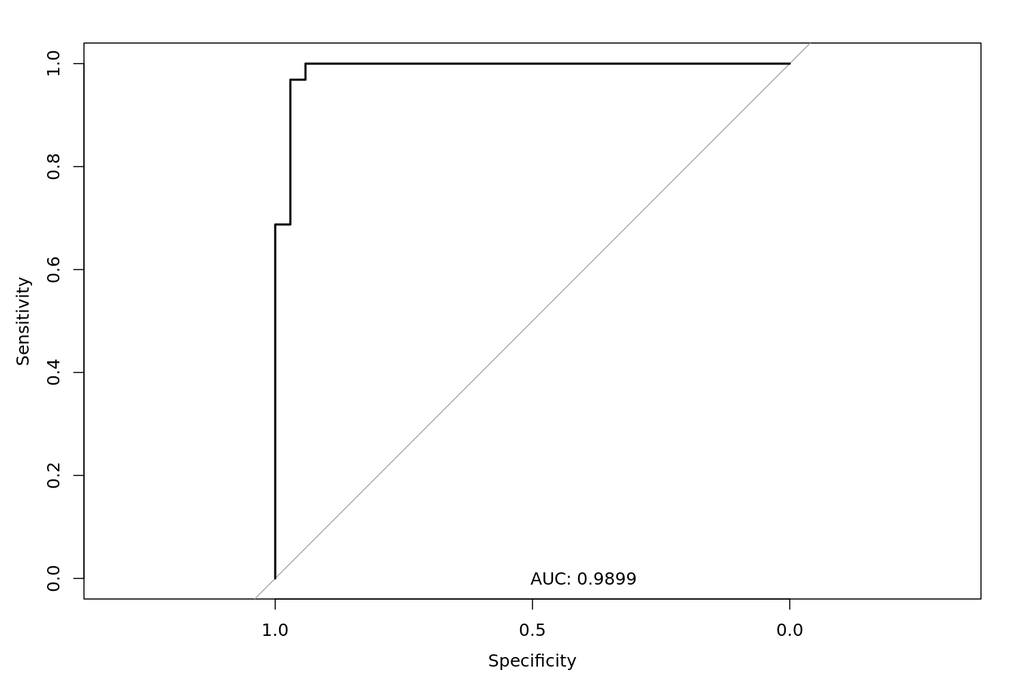

```r
knitr::include_graphics(filename)
```

#### Elastic (min)

```r
validation_results[["GSE102287"]]$elasticnet$min$confmat
```

```
#> Confusion Matrix and Statistics
#>
#>           Reference
#> Prediction  0  1
#>          0 32  1
#>          1  2 31
#>
#>                Accuracy : 0.9545
#>                  95% CI : (0.8729, 0.9905)
#>     No Information Rate : 0.5152
#>     P-Value [Acc > NIR] : 3.899e-15
#>
#>                   Kappa : 0.9091
#>
#>  Mcnemar's Test P-Value : 1
#>
#>             Sensitivity : 0.9688
#>             Specificity : 0.9412
#>          Pos Pred Value : 0.9394
#>          Neg Pred Value : 0.9697
#>              Prevalence : 0.4848
#>          Detection Rate : 0.4697
#>    Detection Prevalence : 0.5000
#>       Balanced Accuracy : 0.9550
#>
#>        'Positive' Class : 1
#>
```

```r
# create roc plot
filename <- paste0(plotdir, "ROC_validation_GSE102287_elasticnet_min.png")
sigident::plot_rocplot(roc = validation_results[["GSE102287"]]$elasticnet$min$roc,
                       filename = filename)
```

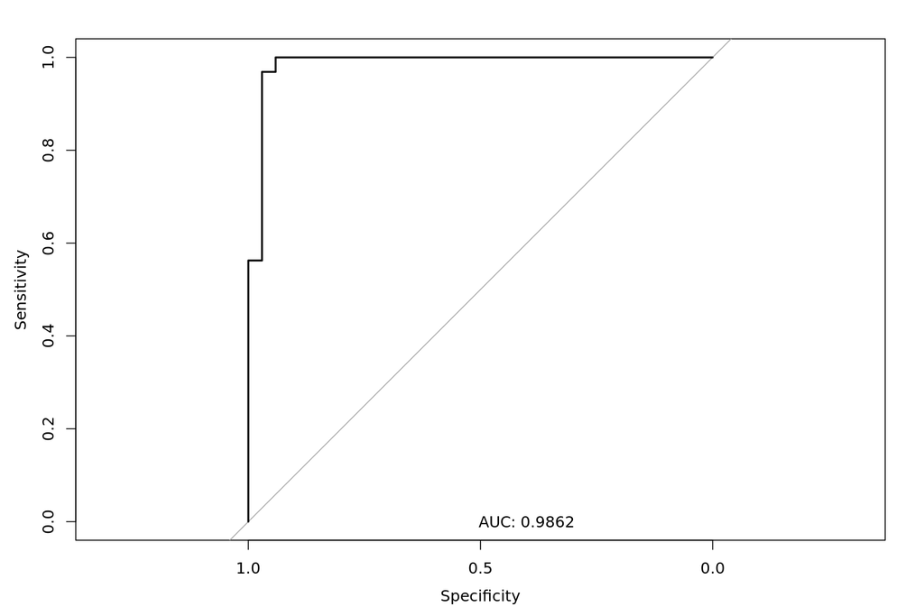

```r
knitr::include_graphics(filename)
```

#### Elastic (1se)

```r
validation_results[["GSE102287"]]$elasticnet[["1se"]]$confmat
```

```
#> Confusion Matrix and Statistics
#>
#>           Reference
#> Prediction  0  1
#>          0 33  1
#>          1  1 31
#>
#>                Accuracy : 0.9697
#>                  95% CI : (0.8948, 0.9963)
#>     No Information Rate : 0.5152
#>     P-Value [Acc > NIR] : <2e-16
#>
#>                   Kappa : 0.9393
#>
#>  Mcnemar's Test P-Value : 1
#>
#>             Sensitivity : 0.9688
#>             Specificity : 0.9706
#>          Pos Pred Value : 0.9688
#>          Neg Pred Value : 0.9706
#>              Prevalence : 0.4848
#>          Detection Rate : 0.4697
#>    Detection Prevalence : 0.4848
#>       Balanced Accuracy : 0.9697
#>
#>        'Positive' Class : 1
#>
```

```r
# create roc plot
filename <- paste0(plotdir, "ROC_validation_GSE102287_elasticnet_1se.png")
sigident::plot_rocplot(roc = validation_results[["GSE102287"]]$elasticnet[["1se"]]$roc,
                       filename = filename)
```

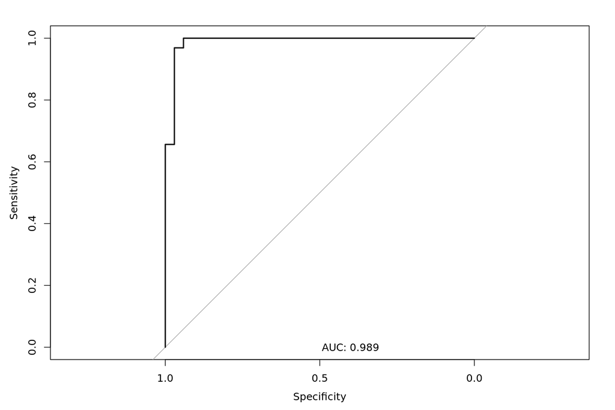

```r
knitr::include_graphics(filename)
```

```r
validation_results[["GSE102287"]] <- NULL
rm(validationstudylist, diagnostic_models, GSE102287, GSE33356)
gc()
```

# Identification of prognostic signatures

## Create a list that contains specifications of the study/studies that contain(s) survival time information

For the calculation of a prognostic signature it is first required to transform the phenoData containing the relevant survival data. In our example, only the study GSE19188 contains information on a subjects survival.  
In order to make the subsequent analyses possible, the list `discoverystudies_w_timedata`, containing metainformation about the validation study needs to be created. This nested list needs to contain the following elements:  
* the studyname, which is the key for a list containing  
+ `setid`: the index of the provided GEO set to be used  
+ `timecol`: the phenoData columm name of the survival time  
+ `status`: a list, containing the elements `statuscol` (name of phenoData column containing the survival status), `levels` (a list containing the originally used level-names of `statuscol`, namely `alive`, `deceased`, `na`)  
+ `targetcolname`: the name of the phenoData column containing the target-variable  
+ `controllevelname`: the level name of the controls of the column, specified in `targetcolname`  
+ `targetlevelname`: the level name of the subjects of interest in `targetcolname`  
+ `use_rawdata`: a logical value (TRUE or FALSE) that indicates, if the study is imported from the raw data

Since we already used the raw data above to load the study ‘GSE19188’ for the analyses of the DEGs, the enrichment analysis and the computation of the diagnostic signature, we here again import the study from the raw CEL files.

```r
discoverystudies_w_timedata <- list(
  "GSE19188" = list(
    setid = 1,
    timecol = "characteristics_ch1.2",
    status = list(
      statuscol = "characteristics_ch1.3",
      levels = list(alive = "status: alive",
                    deceased = "status: deceased",
                    na = "status: Not available")),
    targetcolname = "characteristics_ch1",
    controllevelname = "tissue type: healthy",
    targetlevelname = "tissue type: tumor",
    use_rawdata = TRUE)
)
```

## Identification of survival correlated genes

### Extract survival data

Next, the survival data needs to be extracted. `get_survival_time` results in a table named `survival_data`, containing samples (in our example of the class tumor) as rows, survival time and if an event (death) happened as columns. Additionally, the expression values of the selected DEGs (provided as parameter ‘genes’) are added as columns to the table.

```r
### Identification of survival correlated genes
survival_data <- sigident::get_survival_time(
  sample_metadata = sample_metadata,
  genes = genes,
  idtype = idtype,
  discoverystudies_w_timedata = discoverystudies_w_timedata,
  datadir = datadir
)
survival_table <- survival_data[["GSE19188"]]
```

```r
dim(survival_table)
```

```
#> [1]  91 701
```

```r
head(survival_table[,1:4])
```

```
#>           time status 217046_s_at 210081_at
#> GSM475656 12.5      2    3.346914  3.799257
#> GSM475661   NA     NA    2.623701  3.281502
#> GSM475662   NA     NA    3.619692  3.489756
#> GSM475664   NA     NA    5.045024  6.039511
#> GSM475668   NA     NA    2.806310  3.556768
#> GSM475670   NA     NA    2.563139  3.281502
```

### Compute univariate cox regression

Subsequently, an univariate Cox regression is conducted to identify survival correlated genes. The results containing the hazard rate within a 95% CI and corresponding p-values are exported as csv-file.

```r
surv_correlated <- sigident::univ_cox(survtable = survival_table,
                                      genes = genes)
# export table with survival correlated genes
data.table::fwrite(surv_correlated,
                   paste0(csvdir, "survival_correlated_genes.csv"))
```

```r
dim(surv_correlated)
```

```
#> [1] 22  5
```

```r
head(surv_correlated)
```

```
#>                      id  beta HR (95% CI for HR) wald_test p_value
#> 224822_at     224822_at -0.28   0.76 (0.62-0.92)       7.5   0.006
#> 210762_s_at 210762_s_at -0.26   0.77 (0.63-0.95)         6   0.015
#> 229367_s_at 229367_s_at -0.22    0.8 (0.66-0.98)       4.7   0.030
#> 205357_s_at 205357_s_at  -0.2      0.82 (0.68-1)         4   0.044
#> 222646_s_at 222646_s_at  0.23        1.3 (1-1.6)         4   0.045
#> 211696_x_at 211696_x_at -0.14      0.87 (0.75-1)         4   0.047
```

## Prognostic classifier and Kaplan-Meier estimator

In order to build an unbiased classifier that speparates subjects into high risk and low risk groups, expression data from the remaining discovery studies are required.

### Evaluate expression pattern (over-/underrepresentation)

The classifier takes the expression profiles of the identified survival correlated genes between tumor and non-tumor samples into account.

```r
classifier_studies <- c("GSE18842", "GSE19804")
expr_pattern <- sigident::generate_expression_pattern(
  classifier_studies = classifier_studies,
  sig_cov = surv_correlated,
  mergeset = mergeset,
  sample_metadata = sample_metadata
)
```

```r
dim(expr_pattern)
```

```
#> [1] 22  2
```

```r
head(expr_pattern)
```

```
#>          Gene Over/Under
#> 1   224822_at      Under
#> 2 210762_s_at      Under
#> 3 229367_s_at      Under
#> 4 205357_s_at      Under
#> 5 222646_s_at       Over
#> 6 211696_x_at      Under
```

### Apply the prognostic classifier on validation dataset

#### Create a list that contains specifications of the study that contains the validation information

```r
validationstudiesinfo <- list(
  "GSE30219" = list(
    setid = 1,
    timecol = "characteristics_ch1.9",
    status = list(
      statuscol = "characteristics_ch1.8",
      levels = list(alive = "status: ALIVE",
                    deceased = "status: DEAD",
                    na = "status: NTL")
    ),
    targetcolname = "source_name_ch1",
    controllevelname = "Non Tumoral Lung",
    targetlevelname = "Lung Tumour"),

  "GSE50081" = list(
    setid = 1,
    timecol = "characteristics_ch1.8",
    status = list(
      statuscol = "characteristics_ch1.9",
      levels = list(
        alive = "status: alive",
        deceased = "status: dead",
        na = NA)
    ),
    targetcolname = "characteristics_ch1.1",
    targetlevelname = paste(
      "histology: adenocarcinoma",
      "histology: adenosquamous carcinoma",
      "histology: large cell carcinoma",
      "histology: NSClarge cell carcinoma-mixed",
      "histology: NSCLC-favor adenocarcinoma",
      "histology: squamous cell carcinoma",
      "histology: squamous cell carcinoma X2",
      sep = "|||"
    ),
    controllevelname = NULL)
)
# if targetlevelname == NULL, the expression set will not be filtered further
# but instead, all samples will be used for calculations
```

```r
p_c <- sigident::prognostic_classifier(
  pattern_com = expr_pattern,
  validationstudiesinfo = validationstudiesinfo,
  datadir = datadir,
  idtype = idtype
)
```

### Validation study: GSE30219

Here we extract information on the study GSE30219.

```r
fit <- p_c[["GSE30219"]]$kaplan_estimator$fit
risktable <- p_c[["GSE30219"]]$risktable
```

```r
dim(risktable)
```

```
#> [1] 293   3
```

```r
head(risktable)
```

```
#>           time status groups
#> GSM748053  121      1      0
#> GSM748054   21      2      0
#> GSM748055   86      2      0
#> GSM748056   10      2      0
#> GSM748057   81      2      0
#> GSM748058   68      1      0
```

#### View proportional hazards regression models

```r
p_c[["GSE30219"]]$kaplan_estimator$res_cox
```

```
#> Call:
#> survival::coxph(formula = survival::Surv(time, status) ~ groups,
#>     data = risktable)
#>
#>          coef exp(coef) se(coef)     z        p
#> groups 0.5491    1.7317   0.1507 3.643 0.000269
#>
#> Likelihood ratio test=13.68  on 1 df, p=0.0002166
#> n= 278, number of events= 188
#>    (15 observations deleted due to missingness)
```

```r
fit
```

```
#> Call: survfit(formula = survival::coxph(survival::Surv(time, status) ~
#>     groups, data = risktable), newdata = new_df)
#>
#>     n events median 0.95LCL 0.95UCL
#> 1 278    188     88      57     134
#> 2 278    188     28      17      50
```

#### Plot prognostic Kaplan-Meier plot

```r
# create roc plot
filename <- paste0(plotdir, "GSE30219_Prognostic_Kaplan-Meier_Plot.png")
sigident::plot_survplot(
  fit = fit,
  risktable = risktable,
  filename = filename
)
```

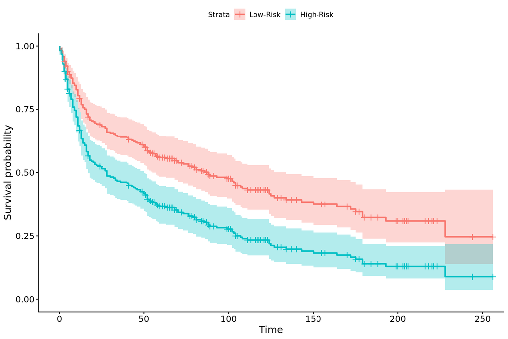

```r
knitr::include_graphics(filename)
```

### Validation study: GSE50081

```r
fit <- p_c[["GSE50081"]]$kaplan_estimator$fit
risktable <- p_c[["GSE50081"]]$risktable
```

```r
dim(risktable)
```

```
#> [1] 181   3
```

```r
head(risktable)
```

```
#>            time status groups
#> GSM1213669 4.11      2      1
#> GSM1213670 7.52      1      0
#> GSM1213671 7.32      1      0
#> GSM1213672 6.84      1      0
#> GSM1213673 1.91      2      1
#> GSM1213674 7.03      1      1
```

#### View proportional hazards regression models

```r
p_c[["GSE50081"]]$kaplan_estimator$res_cox
```

```
#> Call:
#> survival::coxph(formula = survival::Surv(time, status) ~ groups,
#>     data = risktable)
#>
#>          coef exp(coef) se(coef)     z      p
#> groups 0.5089    1.6635   0.2361 2.156 0.0311
#>
#> Likelihood ratio test=4.76  on 1 df, p=0.02919
#> n= 181, number of events= 75
```

```r
fit
```

```
#> Call: survfit(formula = survival::coxph(survival::Surv(time, status) ~
#>     groups, data = risktable), newdata = new_df)
#>
#>     n events median 0.95LCL 0.95UCL
#> 1 181     75   7.74    6.47      NA
#> 2 181     75   5.63    4.11      NA
```

#### Plot prognostic Kaplan-Meier plot

```r
# create roc plot
filename <- paste0(plotdir, "GSE50081_Prognostic_Kaplan-Meier_Plot.png")
sigident::plot_survplot(
  fit = fit,
  risktable =risktable,
  filename = filename
)
```

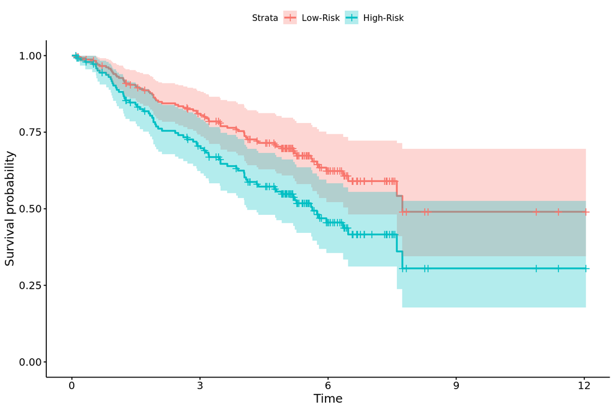

```r
knitr::include_graphics(filename)
```

# An alternative workflow: four generic functions for signature identification

In order to simplify the workflow described above, we wrapped all these functions into four big functions.

## Preprocessing:

The preprocessing of the data needs to be conform with the above described approach. Here, all necessary objects are created, including `mergeset`, `mergedset`, `batch` and `diagnosis`.

### Define Variables

```r
# initialize filePath:
filePath <- tempdir()
maindir <- "./geodata/"
datadir <- paste0(maindir, "data/")
dir.create(maindir)
dir.create(datadir)

# define more variables
plotdir <- "./plots/"
dir.create(plotdir)
csvdir <- "./csv/"
dir.create(csvdir)

# pathway
species <- "Hs"
OrgDb <- "org.Hs.eg.db"
organism <- "hsa"
pathwayid <- "hsa04151"

# diagnostig signature
seed <- 111
split <- 0.8
nfolds <- 10

# other variables
idtype = "affy"
fdr <- 0.05
```

## Run `sigident.func::sigidentDEG`-function

```r
genes <- sigident.func::sigidentDEG(
  mergeset = mergeset,
  mergedset = mergedset,
  sample_metadata = sample_metadata,
  diagnosis = diagnosis,
  idtype = idtype,
  fdr = fdr,
  plotdir = plotdir,
  csvdir = csvdir
)
```

## Run `sigident.func::sigidentEnrichment`-function

```r
sigident.func::sigidentEnrichment(
  mergeset = mergeset,
  mergedset = mergedset,
  idtype = idtype,
  diagnosis = diagnosis,
  species = species,
  org_db = OrgDb,
  organism = organism,
  pathwayid = pathwayid,
  plotdir = plotdir,
  csvdir = csvdir
)
```

```r
filename <- paste0(plotdir, "/", pathwayid, ".png")
knitr::include_graphics(filename)
```

```r
filename <- paste0(plotdir, "/", pathwayid, ".pathview.png")
knitr::include_graphics(filename)
```

## Run `sigidentDiagnostic`-function

```r
diagnostic_models <- sigident::sigidentDiagnostic(
  mergeset = mergeset,
  diagnosis = diagnosis,
  seed = seed,
  nfolds = nfolds,
  split = split,
  plotdir = plotdir
)
```

```r
knitr::kable(
  sigident::compare_diagnostic_models(diagnostic_models)
)
```

```r
knitr::kable(
  sigident::get_diagnostic_lambda_values(diagnostic_models)
)
```

### Validation of the diagnostic signatures

Some users may validate the resulting models using new independent data sets. This can be conducted running the function `validate_diagnostic_signatures`. First, a list containing meta information on the validation study must be created.

```r
validationstudylist <- list(
  "GSE30219" = list(
    setid = 1,
    targetcolname = "source_name_ch1",
    controllevelname = "Non Tumoral Lung",
    targetlevelname = "Lung Tumour"
  ),
  "GSE33356" = list(
    setid = 1,
    targetcolname = "characteristics_ch1",
    controllevelname = "tissue: paired normal adjacent",
    targetlevelname = "tissue: lung cancer"
  ),
  "GSE102287" = list(
    setid = 2,
    targetcolname = "characteristics_ch1.6",
    controllevelname = "tumor_normal status: N",
    targetlevelname = "tumor_normal status: T"
  )
)
```

```r
validation_results <- sigident::validate_diagnostic_signatures(
  validationstudylist = validationstudylist,
  models = diagnostic_models,
  genes = genes,
  idtype = idtype,
  datadir = datadir
)
```

## Run `sigidentPrognostic`-Function

### First, define meta information lists

```r
validationstudiesinfo <- list(
  "GSE30219" = list(
    setid = 1,
    timecol = "characteristics_ch1.9",
    status = list(
      statuscol = "characteristics_ch1.8",
      levels = list(alive = "status: ALIVE",
                    deceased = "status: DEAD",
                    na = "status: NTL")
    ),
    targetcolname = "source_name_ch1",
    controllevelname = "Non Tumoral Lung",
    targetlevelname = "Lung Tumour"),

  "GSE50081" = list(
    setid = 1,
    timecol = "characteristics_ch1.8",
    status = list(
      statuscol = "characteristics_ch1.9",
      levels = list(
        alive = "status: alive",
        deceased = "status: dead",
        na = NA)
    ),
    targetcolname = "characteristics_ch1.1",
    targetlevelname = paste(
      "histology: adenocarcinoma",
      "histology: adenosquamous carcinoma",
      "histology: large cell carcinoma",
      "histology: NSClarge cell carcinoma-mixed",
      "histology: NSCLC-favor adenocarcinoma",
      "histology: squamous cell carcinoma",
      "histology: squamous cell carcinoma X2",
      sep = "|||"
    ),
    controllevelname = NULL)
)
# if targetlevelname == NULL, the expression set will not be filtered further
# but instead, all samples will be used for calculations
```

### Then run the analysis

```r
progn_results <- sigident::sigidentPrognostic(
  mergeset = mergeset,
  sample_metadata = sample_metadata,
  idtype = idtype,
  genes = genes,
  discoverystudies_w_timedata = discoverystudies_w_timedata,
  classifier_studies = c("GSE18842", "GSE19804"),
  validationstudiesinfo = validationstudiesinfo,
  datadir = datadir,
  plotdir = plotdir,
  csvdir = csvdir
)
```

```r
# create roc plot
filename <- paste0(plotdir, "GSE30219_Prognostic_Kaplan-Meier_Plot.png")
```

```r
knitr::include_graphics(filename)
```

```r
# create roc plot
filename <- paste0(plotdir, "GSE50081_Prognostic_Kaplan-Meier_Plot.png")
```

```r
knitr::include_graphics(filename)
```